# 04.09.2026 Travkin Maksim 09.07.14p1

### Задание 1. Загрузка данных

```python
import pandas as pd
import numpy as np
import matplotlib.pyplot as plt
```

- Загрузка и считывание файла

```python
df = pd.read_csv('spotify_artist_streaming_2020_2025.csv')
```

### Задание 2. Первичное знакомство с датасетом

- Вывод датасета

```python
display(df)
```

|  | track_id | track_name | artist_name | album_name | release_date | genre | duration_ms | popularity | danceability | energy | ... | popularity_category | loudness_category | key_name | mode_name | is_explicit_bool | release_quarter | is_weekend_release | log_stream_count | upbeat_score | artist_track_count |
| --- | --- | --- | --- | --- | --- | --- | --- | --- | --- | --- | --- | --- | --- | --- | --- | --- | --- | --- | --- | --- | --- |
| 0 | 346d85e2-ffde-41b3-854a-589ed880b91f | Storm | Ethereal | The Hollow Journeys | 2021-10-06 | Pop | 169594 | 47 | 0.6777 | 0.7949 | ... | Medium | Loud | A | Major | False | Q4 | False | 10.7492 | 0.6632 | 3232 |
| 1 | 12bc268a-363b-4f19-8fa8-0ced7ae1e462 | Silent | The Wolfs | Ancient Thunder | 2024-10-26 | K-Pop | 256755 | 26 | 0.9405 | 0.7163 | ... | Medium | Moderate | C# | Major | False | Q4 | True | 8.5895 | 0.7615 | 20 |
| 2 | 30d627d9-878d-4bb3-be59-71feb6ed4f3f | Shattered Lines | LolaOre | Twisted Harbors | 2022-11-12 | Punk | 170212 | 46 | 0.6853 | 0.9500 | ... | Medium | Loud | E | Major | False | Q4 | True | 12.2935 | 0.7828 | 199 |
| 3 | 85501bb9-d221-4339-9e2e-29b1b3daff0a | Breaking Roses | Clay Black | The Blinding Letters | 2020-06-22 | Pop | 181250 | 4 | 0.7817 | 0.6943 | ... | Low | Moderate | F# | Major | False | Q2 | False | 8.5658 | 0.6778 | 693 |
| 4 | 7bf92bd2-c6fe-4869-a90e-242bb8bbe7a3 | Lines | Knot Hart | The Cosmic Letters | 2024-01-22 | Latin | 160894 | 27 | 0.7200 | 0.4958 | ... | Medium | Moderate | C# | Major | False | Q1 | False | 10.2191 | 0.5494 | 12111 |
| ... | ... | ... | ... | ... | ... | ... | ... | ... | ... | ... | ... | ... | ... | ... | ... | ... | ... | ... | ... | ... | ... |
| 49995 | 38913908-e3ab-42a2-9a97-2d1847c21e3b | Flames | Luna Ink | The Shattered Tapes | 2025-02-27 | Hip-Hop | 249380 | 6 | 0.7338 | 0.8172 | ... | Low | Loud | C# | Major | False | Q1 | False | 6.2005 | 0.7545 | 577 |
| 49996 | 83653402-ca85-4583-b7ec-13ab3e82888e | Love | Knot Hart | Young II | 2021-07-25 | Folk | 176329 | 22 | 0.5547 | 0.0000 | ... | Low | Quiet | A# | Minor | True | Q3 | True | 9.1916 | 0.3292 | 12111 |
| 49997 | 4398dd33-ecfc-4c1a-ab9e-248f38082318 | The Waves | Jasper Jade | The Burning Journeys | 2023-12-24 | Pop | 202472 | 5 | 0.6558 | 0.8805 | ... | Low | Moderate | G | Major | True | Q4 | True | 7.8200 | 0.6794 | 181 |
| 49998 | 07c673e7-39a5-4c28-8789-163ae5f17f3f | Flying Eyes | ElaraRain | Frequencies | 2020-08-17 | Rock | 172542 | 81 | 0.5979 | 0.6252 | ... | Very High | Moderate | F# | Minor | False | Q3 | False | 15.1911 | 0.5622 | 1111 |
| 49999 | 888e233c-e7fd-4c0d-af8a-3cd98345a64e | Roads | Edge Brooks | Wicked III | 2020-11-19 | Hip-Hop | 198469 | 27 | 0.9388 | 0.6830 | ... | Medium | Moderate | G# | Minor | True | Q4 | False | 9.3957 | 0.7795 | 65 |

50000 rows × 33 columns

- Выведите первые 10 строк таблицы

```python
display(df.head(10))
```

|  | track_id | track_name | artist_name | album_name | release_date | genre | duration_ms | popularity | danceability | energy | ... | popularity_category | loudness_category | key_name | mode_name | is_explicit_bool | release_quarter | is_weekend_release | log_stream_count | upbeat_score | artist_track_count |
| --- | --- | --- | --- | --- | --- | --- | --- | --- | --- | --- | --- | --- | --- | --- | --- | --- | --- | --- | --- | --- | --- |
| 0 | 346d85e2-ffde-41b3-854a-589ed880b91f | Storm | Ethereal | The Hollow Journeys | 2021-10-06 | Pop | 169594 | 47 | 0.6777 | 0.7949 | ... | Medium | Loud | A | Major | False | Q4 | False | 10.7492 | 0.6632 | 3232 |
| 1 | 12bc268a-363b-4f19-8fa8-0ced7ae1e462 | Silent | The Wolfs | Ancient Thunder | 2024-10-26 | K-Pop | 256755 | 26 | 0.9405 | 0.7163 | ... | Medium | Moderate | C# | Major | False | Q4 | True | 8.5895 | 0.7615 | 20 |
| 2 | 30d627d9-878d-4bb3-be59-71feb6ed4f3f | Shattered Lines | LolaOre | Twisted Harbors | 2022-11-12 | Punk | 170212 | 46 | 0.6853 | 0.9500 | ... | Medium | Loud | E | Major | False | Q4 | True | 12.2935 | 0.7828 | 199 |
| 3 | 85501bb9-d221-4339-9e2e-29b1b3daff0a | Breaking Roses | Clay Black | The Blinding Letters | 2020-06-22 | Pop | 181250 | 4 | 0.7817 | 0.6943 | ... | Low | Moderate | F# | Major | False | Q2 | False | 8.5658 | 0.6778 | 693 |
| 4 | 7bf92bd2-c6fe-4869-a90e-242bb8bbe7a3 | Lines | Knot Hart | The Cosmic Letters | 2024-01-22 | Latin | 160894 | 27 | 0.7200 | 0.4958 | ... | Medium | Moderate | C# | Major | False | Q1 | False | 10.2191 | 0.5494 | 12111 |
| 5 | e4a536ca-c6d4-4bad-97b5-d5e7b85c49e2 | Wild Doors | Knot Hart | Jagged Gardens | 2021-04-12 | R&B | 198179 | 28 | 0.6538 | 0.3732 | ... | Medium | Moderate | G# | Major | False | Q2 | False | 9.8292 | 0.4586 | 12111 |
| 6 | 305b4f13-b2ac-47e9-a6f2-d0c15934f8b6 | Skies | Knot Hart | The Ancient Tapes | 2025-07-16 | R&B | 251330 | 18 | 0.7399 | 0.4000 | ... | Low | Moderate | G | Minor | False | Q3 | False | 9.6072 | 0.5475 | 12111 |
| 7 | 83c3a6be-6066-449a-a339-19afcde7cfb3 | Wild | Blaze Project | Crystal | 2023-12-12 | Classical | 208198 | 15 | 0.1730 | 0.3085 | ... | Low | Moderate | G# | Major | True | Q4 | False | 6.9745 | 0.2482 | 53 |
| 8 | 437961fc-9ccd-4c86-8eb7-e96b6d2dc5c8 | Neon Oceans | Clay Black | Broken V | 2020-06-17 | Pop | 254751 | 23 | 0.6838 | 0.5026 | ... | Low | Moderate | G | Minor | True | Q2 | False | 8.3301 | 0.5249 | 693 |
| 9 | 53df0c89-adc4-48b7-94e3-111e348cb17b | Eternal Angels | Phantasm | The Kind Notes | 2020-06-09 | Trap | 310076 | 39 | 0.5759 | 0.8349 | ... | Medium | Moderate | D# | Minor | False | Q2 | False | 12.1223 | 0.6488 | 242 |

10 rows × 33 columns

- Определите количество строк и столбцов

```python
rows, cols = df.shape
print(f"Количество строк: {rows}")
print(f"Количество столбцов: {cols}")
```

```
Количество строк: 50000
Количество столбцов: 33
```

- Выведите названия всех столбцов

```python
print(df.columns.tolist())
```

[output not shown]

- Посмотрите типы данных столбцов

```python
print(df.dtypes)
```

```
track_id                object
track_name              object
artist_name             object
album_name              object
release_date            object
genre                   object
duration_ms              int64
popularity               int64
danceability           float64
energy                 float64
key                      int64
loudness               float64
mode                     int64
instrumentalness       float64
tempo                  float64
stream_count             int64
country                 object
explicit                  bool
label                   object
release_year             int64
release_month            int64
release_day_of_week     object
duration_minutes       float64
popularity_category     object
loudness_category       object
key_name                object
mode_name               object
is_explicit_bool          bool
release_quarter         object
is_weekend_release        bool
log_stream_count       float64
upbeat_score           float64
artist_track_count       int64
dtype: object
```

### Задание 3. Сортировка данных

- Найдите 10 треков с максимальным количеством прослушиваний (stream_count)

```python
top_10_tracks = df.nlargest(10, 'stream_count')
```

```python
print("10 треков с максимальным количеством прослушиваний:")
display(top_10_tracks[['track_name', 'artist_name', 'genre', 'stream_count', 'release_year']])
```

```
10 треков с максимальным количеством прослушиваний:
```

|  | track_name | artist_name | genre | stream_count | release_year |
| --- | --- | --- | --- | --- | --- |
| 1528 | The Roses | Grove Nova | Alternative | 43345015 | 2024 |
| 36998 | Bitter | Flora Quinn | Rock | 26635547 | 2022 |
| 42813 | The Streets | Ethereal | Pop | 26314312 | 2020 |
| 21643 | Breaking Thunder | SethStone | Metal | 20408155 | 2020 |
| 49193 | The Pages | IsleEyre | Pop | 19265301 | 2023 |
| 26622 | Lights | Dean System | Hip-Hop | 17238449 | 2024 |
| 45015 | Gentle | Rocco Ore | R&B | 15776187 | 2021 |
| 39012 | Storm | Knot Hart | R&B | 14545933 | 2023 |
| 29091 | Burning Islands | The Inks | Pop | 14507867 | 2020 |
| 13635 | Broken Eyes | Prism Hart | R&B | 14367106 | 2024 |

- Какие исполнители и жанры встречаются среди самых прослушиваемых треков?

```python
print("Уникальные исполнители из топ 10:")
print(top_10_tracks['artist_name'].unique())
```

```
Уникальные исполнители из топ 10:
['Grove Nova' 'Flora Quinn' 'Ethereal' 'SethStone' 'IsleEyre'
 'Dean System' 'Rocco Ore' 'Knot Hart' 'The Inks' 'Prism Hart']
```

```python
print("Уникальные жанры из топ 10:")
print(top_10_tracks['genre'].unique())
```

```
Уникальные жанры из топ 10:
['Alternative' 'Rock' 'Pop' 'Metal' 'Hip-Hop' 'R&B']
```

### Задание 4. Фильтрация

- Найдите треки после 2024 (release_year)

```python
tracks_after_2024 = df[df['release_year'] > 2024]
print("Количество треков, выпущенных после 2024 года: ")
print(f"{len(tracks_after_2024)}")
```

```
Количество треков, выпущенных после 2024 года:
8318
```

### Задание 5. Основные статистические показатели

- Найти среднее и медиану для popularity

```python
print(f"Среднее значение (mean): {df['popularity'].mean():.2f}")
```

```
Среднее значение (mean): 28.14
```

```python
print(f"Медианное значение (median): {df['popularity'].median():.2f}")
```

```
Медианное значение (median): 26.00
```

- Минимум, максимум и стандартное отклонение для popularity

(можно сделать одной командой, но объяснить, что чем является)

```python
print(f"Минимальное значение (min): {df['popularity'].min()}")
```

```
Минимальное значение (min): 0
```

```python
print(f"Максимальное значение (max): {df['popularity'].max()}")
```

```
Максимальное значение (max): 92
```

```python
print(f"Стандартное отклонение (std): {df['popularity'].std():.2f}")
```

```
Стандартное отклонение (std): 16.00
```

### Задание 6. Мода

Найдите наиболее часто встречающееся значение (моду):

- Для столбца genre

```python
mode_genre = df['genre'].mode()
print(f"Мода для столбца genre: {mode_genre.values}")
```

```
Мода для столбца genre: ['R&B']
```

- Для столбца release_year

```python
mode_release_year = df['release_year'].mode()
print(f"Мода для столбца release_year: {mode_release_year.values}")
```

```
Мода для столбца release_year: [2024]
```

### Задание 7. Гистограмма

Постройте гистограмму распределения значений popularity.

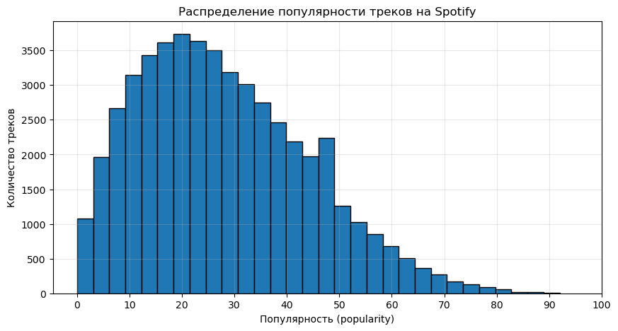

```python
plt.figure(figsize=(10, 5))
plt.hist(df['popularity'], bins=30, edgecolor='black')
plt.title('Распределение популярности треков на Spotify')
plt.xlabel('Популярность (popularity)')
plt.ylabel('Количество треков')
plt.grid(True, alpha=0.3)
plt.xticks(range(0, 101, 10))
plt.show()
```

- В каком диапазоне находится основная часть значений?

В диапазоне от 0 до 60

- Есть ли значения, которые встречаются значительно реже остальных?

Да, от 80 до 100

### Вывод

В ходе работы проведён полный цикл анализа датасета о популярности треков на Spotify. Выполнены загрузка и первичное знакомство с данными, а также их сортировка, фильтрация и вычисление основных показателей.

### Контрольные вопросы

1. Что такое DataFrame?

Двумерная табличная структура данных с подписанными строками и столбцами.

2. Что такое признак (Feature)?

Отдельный столбец в наборе данных, описывающий одну характеристику объектов.

3. Чем среднее арифметическое отличается от медианы?

Среднее — сумма значений, делённая на их количество; медиана — значение в середине упорядоченного ряда.

4. Что показывает гистограмма?

Распределение частот числовых данных по интервалам.

5. Для чего нужна фильтрация данных?

Для выборки строк, удовлетворяющих заданному условию.